# work_stanley

## Egg Amount Predictor Shiny App

All of our analyses on our data set’s variables have been bivariate so far. However, bivariate analyses don’t account for other variables’ influences on a dependent variable in its correlation. Using multiple regression analysis, we can use multiple predictor variables to predict a dependent variable and see the strength each variable has in influencing it.

**Creating the Regression Formula for App**

```r
egg_calculator <- lm(formula=n_eggs ~ predicted_n + bare_ground + veg + sward_height + plant_area + average_leaf_size + temperature_ambient + temperature_soil, data=plant_joined) # create a multiple regression formula
egg_calculator_residuals <- egg_calculator$residuals
```

**Create QQ Plot**

A QQ Plot can be used in conjunction with a multiple regression analysis to see whether its residuals are normal or not. In the case of this analysis, our data is approximately normal with some skewedness to the right as the plot skews upward.

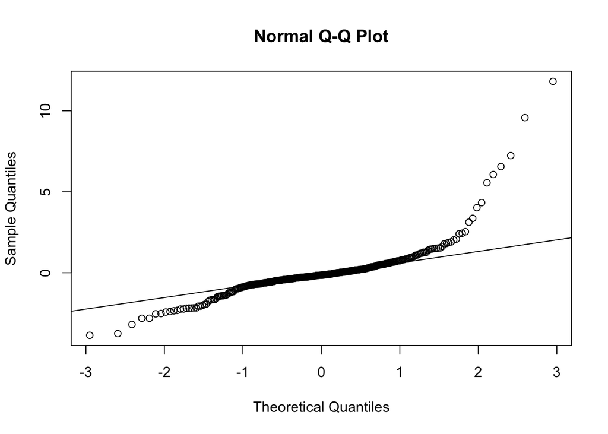

```r
qqnorm(egg_calculator_residuals)
qqline(egg_calculator_residuals)
```

**Print Multiple Regression Model Summary**

We can see the estimated effect each variable of our regression model has on our dependent variable, number of eggs. We can see that in the summary, bare ground, sward height, and soil temperature are strong estimators of the number of eggs as its p values are significantly low, as indicated by the asterisks.

```r
summary(egg_calculator)
```

```
##
## Call:
## lm(formula = n_eggs ~ predicted_n + bare_ground + veg + sward_height +
##     plant_area + average_leaf_size + temperature_ambient + temperature_soil,
##     data = plant_joined)
##
## Residuals:
##     Min      1Q  Median      3Q     Max
## -3.8627 -0.5844 -0.1492  0.3773 11.8215
##
## Coefficients:
##                      Estimate Std. Error t value Pr(>|t|)
## (Intercept)         -7.807953   7.160721  -1.090 0.276398
## predicted_n          0.004153   0.004265   0.974 0.330936
## bare_ground          0.048782   0.010879   4.484 1.04e-05 ***
## veg                  0.004663   0.013148   0.355 0.723118
## sward_height        -0.036172   0.010228  -3.536 0.000468 ***
## plant_area           0.001731   0.001336   1.296 0.195981
## average_leaf_size   -0.001786   0.001814  -0.984 0.325761
## temperature_ambient  0.060499   0.081497   0.742 0.458446
## temperature_soil     0.056880   0.020260   2.808 0.005312 **
## ---
## Signif. codes:  0 '***' 0.001 '**' 0.01 '*' 0.05 '.' 0.1 ' ' 1
##
## Residual standard error: 1.576 on 307 degrees of freedom
##   (2 observations deleted due to missingness)
## Multiple R-squared:  0.3899, Adjusted R-squared:  0.3741
## F-statistic: 24.53 on 8 and 307 DF,  p-value: < 2.2e-16
```

**Code of Actual Shiny Code**

```r
ui <- page_sidebar(
  title = "Egg Calculator Regression",
  sidebar = sidebar(

    # Select predictor variables
    checkboxGroupInput(
      "predictor_vars",
      "Select Predictor Variables:",
      choices = c("predicted_n",
                  "bare_ground",
                  "veg",
                  "sward_height",
                  "plant_area",
                  "average_leaf_size",
                  "temperature_ambient",
                  "temperature_soil"
      ),
      selected = c("predicted_n")
    ),

    # Action button to run regression
    actionButton("run_regression", "Run Regression", class = "btn-primary mt-3")
  ),

  # Main panel with plots and results
  navset_card_tab(
    nav_panel(
      "Scatter Plots",
      card(
        card_header("Egg Count vs Predictor Variables"),
        plotOutput("scatter_plots", height = "600px")
      )
    ),
    nav_panel(
      "Regression Summary",
      card(
        card_header("Model Summary"),
        verbatimTextOutput("regression_summary")
      ),
      card(
        card_header("Model Coefficients"),
        tableOutput("coefficients_table")
      )
    ),
    nav_panel(
      "Diagnostic Plots",
      card(
        card_header("Residual Diagnostics"),
        plotOutput("diagnostic_plots", height = "600px")
      )
    )
  )
)

server <- function(input, output, session) {

  # Fit regression model when button is clicked
  model <- eventReactive(input$run_regression, {
    req(input$predictor_vars)

    # Create formula with egg count as dependent variable
    formula_str <- paste("n_eggs ~", paste(input$predictor_vars, collapse = " + "))
    formula_obj <- as.formula(formula_str)

    # Fit linear model
    lm(formula_obj, data = plant_joined)
  })

  # Scatter plots
  output$scatter_plots <- renderPlot({
    req(input$predictor_vars)

    n_predictors <- length(input$predictor_vars)

    # Calculate grid dimensions
    n_cols <- ceiling(sqrt(n_predictors))
    n_rows <- ceiling(n_predictors / n_cols)

    par(mfrow = c(n_rows, n_cols), mar = c(4, 4, 2, 1))

    for (predictor in input$predictor_vars) {
      plot(plant_joined[[predictor]], plant_joined$n_eggs,
           xlab = predictor,
           ylab = "Egg Count",
           main = paste("Egg Count vs", predictor),
           pch = 19,
           col = rgb(0.2, 0.4, 0.6, 0.6),
           cex = 1.2)

      # Add regression line for visualization
      abline(lm(plant_joined$n_eggs ~ plant_joined[[predictor]]),
             col = "red", lwd = 2)
    }
  })

  # Regression summary
  output$regression_summary <- renderPrint({
    req(model())
    summary(model())
  })

  # Coefficients table
  output$coefficients_table <- renderTable({
    req(model())

    coef_summary <- summary(model())$coefficients
    coef_df <- as.data.frame(coef_summary)
    coef_df$Variable <- rownames(coef_df)
    coef_df <- coef_df[, c("Variable", "Estimate", "Std. Error", "t value", "Pr(>|t|)")]
    rownames(coef_df) <- NULL

    coef_df
  }, digits = 4)

  # Diagnostic plots
  output$diagnostic_plots <- renderPlot({
    req(model())

    par(mfrow = c(2, 2))
    plot(model())
  })
}

shinyApp(ui, server)
```

Shiny applications not supported in static R Markdown documents

## Limitations Of Data and Correlations

The data collected and used for the correlations in our study is specifically from the Shotover Country Park in Oxfordshire, United Kingdom. The only the plant species used in this data was Rumex acetosa or sorrel, which limits the study to butterflies that specialize in consuming this plant, specifically Lycaena phlaeas. This may impact the validity of our study because the data sample isn’t representative of plants and butterflies throughout the world and our study’s findings may not generalize to them. Future studies on the trade-off between plant nutritional value and egg-laying preference could be done in other areas of the world, on other species of plants, and other species of butterflies.